# Usando Rstudio en una busqueda en Twitter

Efrain Juarez

9/9/2020

**INTRODUCCIÓN**

Twitter es una fuente de información para estudio de Social Media. Este informe pretender que sea una manual para extracción y procesamiento de datos. Dando un análisis tuits que los usuarios comentan acerca una búsqueda en Twitter.

**DE LA OBTENCION DE LA INFORMACIÓN TWITTER**

Para poder extraer datos de Twitter es necesario estar registrado en la plataforma y, a partir de la cuenta, crear una Twitter App asociada. Twitter App es el mecanismo que proporciona Twitter para desarrolladores que quieran acceder a los contenidos de Twitter a través de programas. Al crear una Twitter App, Twitter proporciona una serie de claves y tokens de identificación que permiten acceder a la aplicación y extraer información.

```r
create_token(
        app = "nombre del proyecto","xx4X9xxxxgDvt0hZ15878xxy","xy5844o24iOkw7GpEbMxxxxdegetrgege",
        access_token = "987745548844454455-jhfwigfigwvwvwbvhbwvjbwvhbwhv528774xxx",
        access_secret = "HGSDSDSVDVHDVSHDVHSHDS874545445",
        set_renv = TRUE

  )
```

Posteriormente solicitamos los datos de la palabra avión presidencial. También puede hacerse una búsqueda por múltiples términos. Por ejemplo, buscando “avión+presidencial” hace que Twitter devuelva resultados donde las palabras aparecen juntas y en ese orden; como alternativa, al optar por “avión presidencial” se obtienen tweets donde aparezcan esas palabras en cualquier parte del texto, sin importar su orden o si aparecen contiguas.

Donde conseguimos 31,840 datos

```r
avionPMex1 <- search_tweets(q = "avión+presidencial", n = 18000, retryonratelimit = TRUE)
```

**PROCESO DE MANJEO DE DATAFRAME**

Ahora separamos las columnas fecha y hora y las llevamos a tipo numérico.

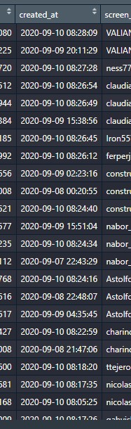

Columa de fechas

Separamos la columna created_at en Fecha, Hora y la Fecha en Periodo, Mes y Día sin perder el origen

```r
avionPMex1 <-
  avionPMex1 %>%
  separate(created_at, into = c("Fecha", "Hora"), sep = " ",remove = FALSE) %>% separate(Fecha, into = c("Periodo","Mes","Dia"), sep = "-",remove = FALSE)
```

Y la Hora en horas, minutos, segundos. Sin perder el origen

```r
avionPMex1 <- avionPMex1 %>% separate(Hora, into = c("horas","minutos","segundos"), sep = ":",remove = FALSE)
```

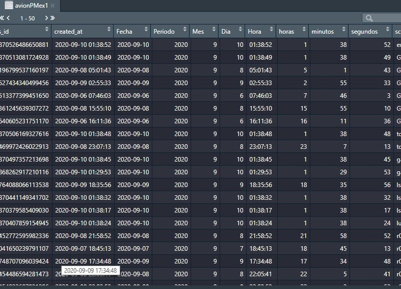

Separados los datos

Vamos a convertir a tipo numérico las columnas de periodo , mes, horas, minutos y segundos, verificando el tipo de entrada yla salida

```r
class(avionPMex1$Periodo)
class(avionPMex1$Mes)
class(avionPMex1$Dia)
class(avionPMex1$horas)
class(avionPMex1$minutos)
class(avionPMex1$segundos)

avionPMex1$Periodo <- as.numeric(avionPMex1$Periodo)
avionPMex1$Mes <- as.numeric(avionPMex1$Mes)
avionPMex1$Dia <- as.numeric(avionPMex1$Dia)
avionPMex1$horas <- as.numeric(avionPMex1$horas)
avionPMex1$minutos <- as.numeric(avionPMex1$minutos)
avionPMex1$segundos <- as.numeric(avionPMex1$segundos)

class(avionPMex1$Periodo)
class(avionPMex1$Mes)
class(avionPMex1$Dia)
class(avionPMex1$horas)
class(avionPMex1$minutos)
class(avionPMex1$segundos)
```

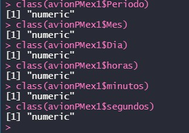

Tipo de dato numérico

Verificamos en que idiomas están los datos y cuantos hay

```r
table(avionPMex1$lang)
```

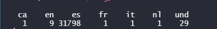

Cantidades de idiomas

Generar una nueva dataframe denominado avionPMex2 que tenga únicamente los idiomas “en” y “es”

```r
avionPMex2 <- avionPMex1 %>% filter(avionPMex1$lang =="en" | avionPMex1$lang=="es")
```

Verificamos como quedaron los idiomas en el nuevo dataframe de los tuits

```r
table(avionPMex2$lang)
```

[output not shown]

Verificamos los encabezados en la base de datos que creamos avionPMex2

```r
names(avionPMex2)
```

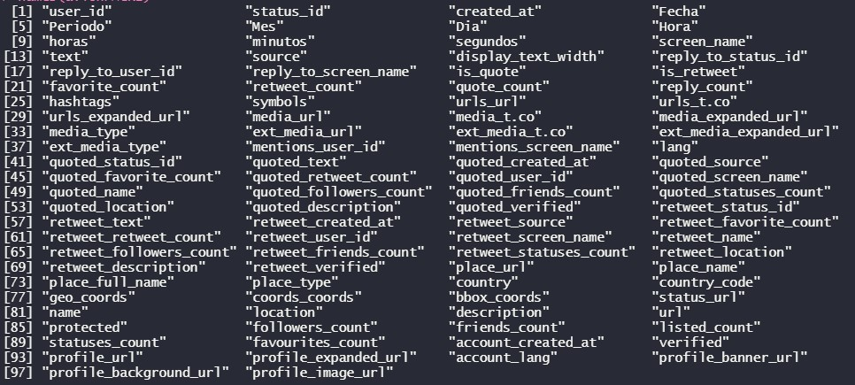

Encabezados

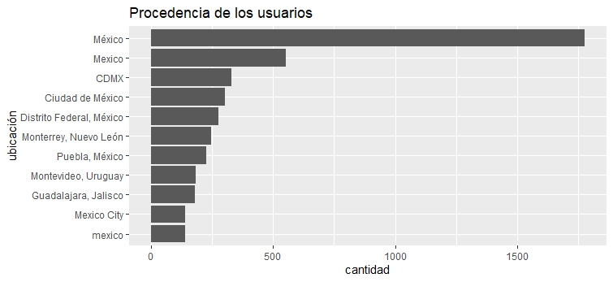

Top

```r
avionPMex2 %>%
    filter(location != "", !is.na(location)) %>%
    count(location) %>%
    top_n(10, n) %>%
    ggplot() +
      geom_col(aes(x = reorder(location, n), y = n)) +
      coord_flip() +
      labs(title = "Procedencia de los usuarios",
           x = "ubicación",
           y = "cantidad")
```

Y vemos que no esta estandarizada la ubicación

Generar una nueva dataframe de avionPMex2 que tenga únicamente algunos datos y columnas en la dataframe avionPMex3

```r
avionPMex3 <- data.frame(Fecha=avionPMex2$Fecha,Periodo=avionPMex2$Periodo,Mes=avionPMex2$Mes,Dia=avionPMex2$Dia,Hora=avionPMex2$Hora,Horas=avionPMex2$horas,Minutos=avionPMex2$minutos,Segundos=avionPMex2$segundos,Text=avionPMex2$text,lenguaje=avionPMex2$lang)
```

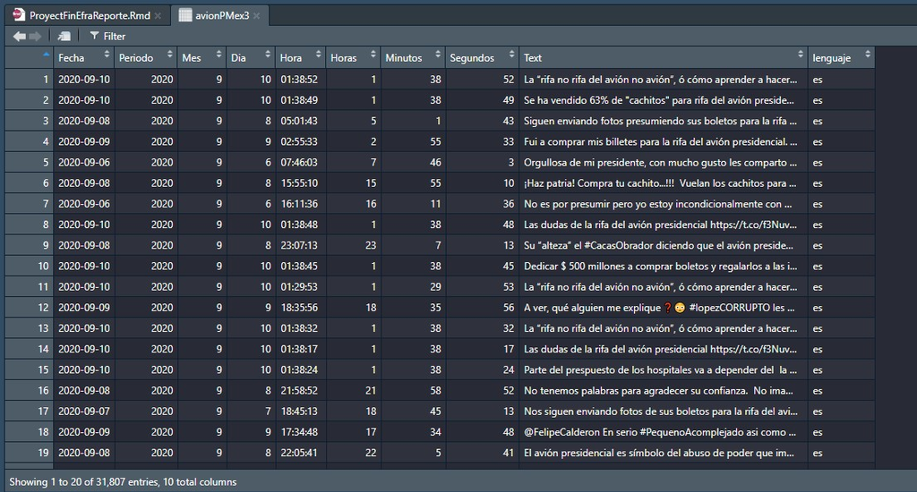

En este momento ya podemos exportar el data frame, desarrollado para publicación y uso en csv

```r
write.csv(x = avionPMex3, file = "avionPMex3.csv", row.names = FALSE)
```

Ahora descargamos el lexico “es” y “en”

```r
download.file("https://raw.githubusercontent.com/jboscomendoza/rpubs/master/sentimientos_afinn/lexico_afinn.en.es.csv",           "lexico_afinn.en.es.csv")
```

importamos el lexico a R

```r
afinn <- read.csv("lexico_afinn.en.es.csv", stringsAsFactors = F, fileEncoding = "latin1") %>% tbl_df()
```

Preparamos el tema (consultar libro de ggplot2)

```r
tema_graf <-
  theme_minimal() +
  theme(text = element_text(family = "serif"),
        panel.grid.minor = element_blank(),
        strip.background = element_rect(fill = "#EBEBEB", colour = NA),
        legend.position = "none",
        legend.box.background = element_rect(fill = "#EBEBEB", colour = NA))
```

Realizamos la calificación de las palabras de Text

```r
avionPMex4 <-
  avionPMex3 %>%
  unnest_tokens(input = "Text", output = "Palabra") %>%
  inner_join(afinn, ., by = "Palabra") %>%
  mutate(Tipo = ifelse(Puntuacion > 0, "Positiva", "Negativa"))
```

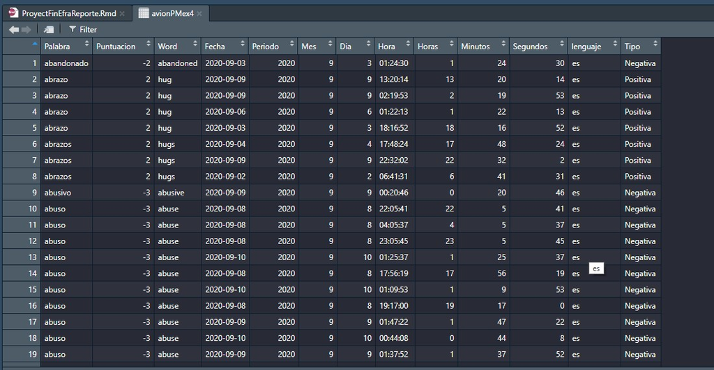

Visualización de sentimientos por idioma

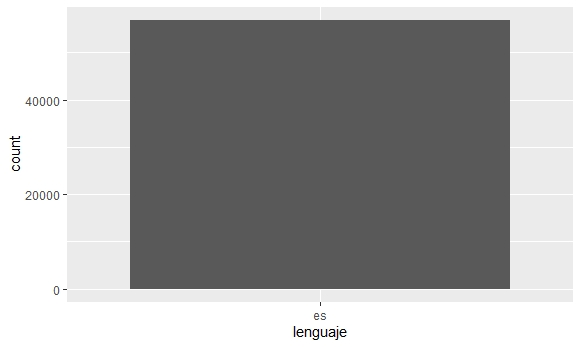

```r
ggplot(data = avionPMex4) +
  geom_bar(mapping = aes(x = lenguaje))
```

Y nos damos cuenta que al realizar esto se solo quedan en español

Verificando como queda la columna de Lenguaje en

```r
table(avionPMex4$lenguaje)
```

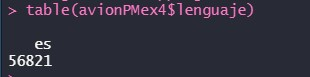

Visualización de sentimientos por Tipo agregando como referencia el lenguaje

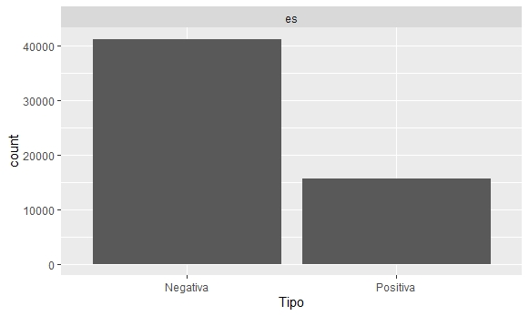

```r
ggplot(data = avionPMex4) +
  geom_bar(mapping = aes(x = Tipo)) + facet_wrap(~ lenguaje, nrow = 2)
```

**OBSERVACIONES**.

Con esta gráfica, podemos visualizar que el impacto del evento fue negativo en general, hablando solamente de español, y nos damos cuenta de que en español tuvo mucho impacto

Este análisis es cuantitativo basado en las gráficas, ahora proporcionaremos análisis cualitativo.

Español positivo

```r
sum((avionPMex4$lenguaje=="es")&(avionPMex4$Tipo=="Positiva"))
```

[output not shown]

Español Negativo

```r
sum((avionPMex4$lenguaje=="es")&(avionPMex4$Tipo=="Negativa"))
```

[output not shown]

visualización de sentimientos por palabra

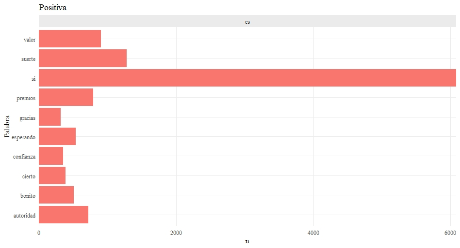

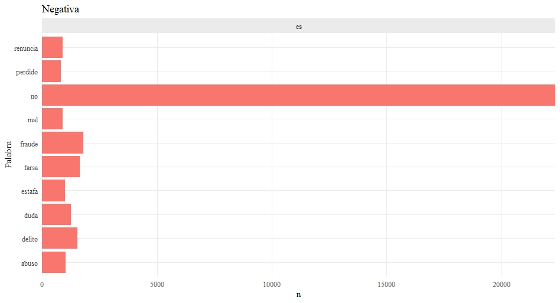

```r
map(c("Positiva", "Negativa"), function(sentimiento) {
  avionPMex4 %>%
    filter(Tipo ==  sentimiento) %>%
    group_by(lenguaje) %>%
    count(Palabra, sort = T) %>%
    top_n(n = 10, wt = n) %>%
    ggplot() +
    aes(Palabra, n, fill = lenguaje) +
    geom_col() +
    facet_wrap("lenguaje", scales = "free") +
    scale_y_continuous(expand = c(0, 0)) +
    coord_flip() +
    labs(title = sentimiento) +
    tema_graf
})
```

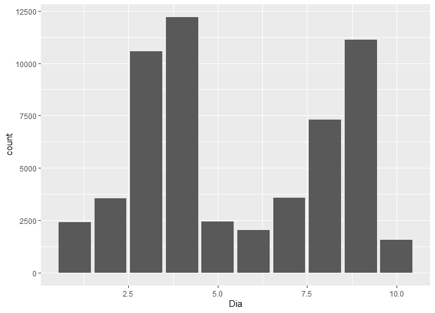

```r
ggplot(data = avionPMex4) +
  geom_bar(mapping = aes(x = Dia))
```

Filtrara la palabra no en nuevo data frame avionPMex5

```r
 avionPMex5 <-
  avionPMex4 %>%
  filter(Palabra != "no")
```

Visualizacion de sentimientos por palabra sin “no” en data frame avionPMex5

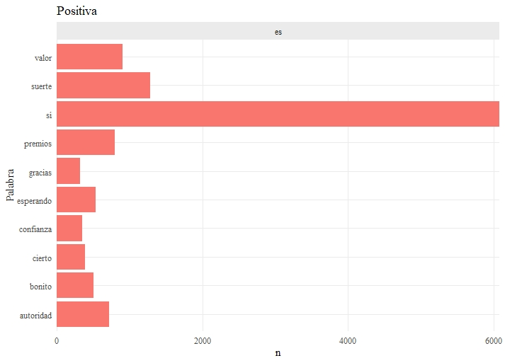

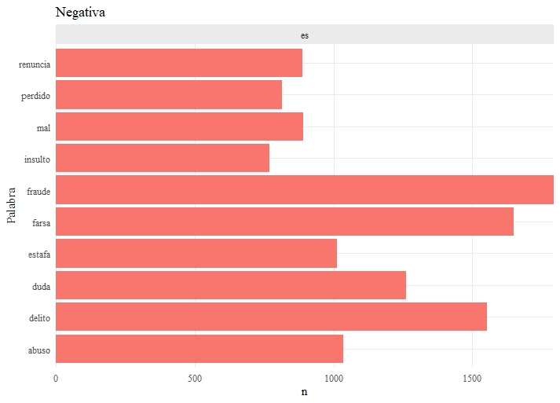

```r
map(c("Positiva", "Negativa"), function(sentimiento) {
  avionPMex5 %>%
    filter(Tipo ==  sentimiento) %>%
    group_by(lenguaje) %>%
    count(Palabra, sort = T) %>%
    top_n(n = 10, wt = n) %>%
    ggplot() +
    aes(Palabra, n, fill = lenguaje) +
    geom_col() +
    facet_wrap("lenguaje", scales = "free") +
    scale_y_continuous(expand = c(0, 0)) +
    coord_flip() +
    labs(title = sentimiento) +
    tema_graf
})
```

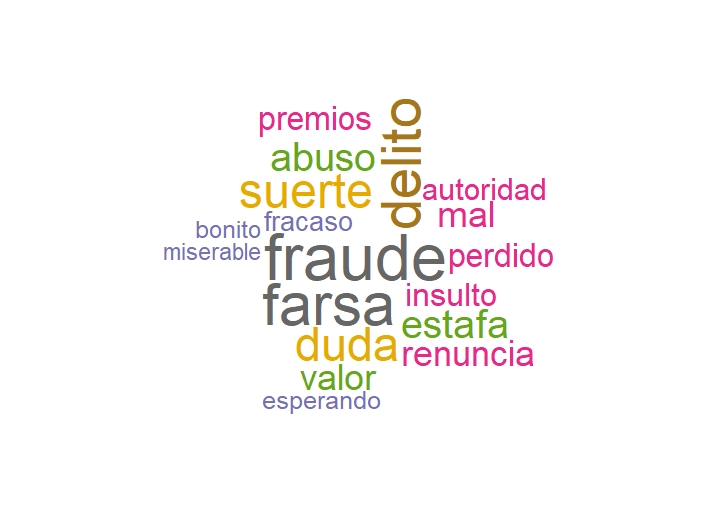

```r
wordcloud(avionPMex5$Palabra, max.words = 200, random.order = F, colors = brewer.pal(name = "Dark2", n=8))
```